# DATA 607 Week 5 Homework

Henry Otuadinma

27 February 2019

# Tidying and Transforming data

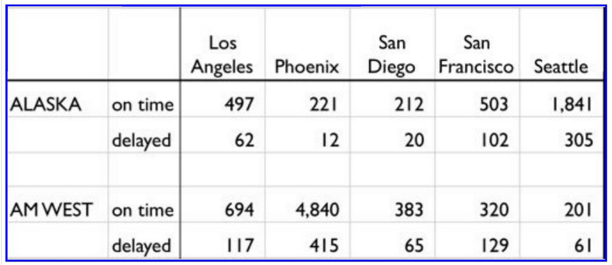

```r
knitr::include_graphics('https://raw.githubusercontent.com/henryvalentine/MSDS2019/master/Classes/DATA%20607/Home%20works/Week5/departures.png')
```

The chart above describes arrival delays for two airlines across five destinations. Your task is to:

## Create a .CSV file from data

1. Create a .CSV file (or optionally, a MySQL database!) that includes all of the information above. You’re encouraged to use a “wide” structure similar to how the information appears above, so that you can practice tidying and transformations as described below.

All tidying and transformation activities will be performed using appropriate functions from the `tidyr` and `dplyr` packages

First, the above information was manually captured as comma separated values and stored in a .csv file Let’s read the .csv file to see how the data looks

## Read .csv file, clean and transform data

2. Read the information from your .CSV file into R, and use tidyr and dplyr as needed to tidy and transform your data.

```r
untidyData <- read.csv("airlineDepartures.csv", header = TRUE, stringsAsFactors = FALSE) # Read the .csv file
untidyData
```

```
##         X     X.1 Los.Ageles Phoenix San.Diego San.Francisco Seattle
## 1  ALASKA on time        497     221       212           503    1841
## 2         delayed         62      12        20           102     305
## 3                         NA      NA        NA            NA      NA
## 4 AM WEST on time        694    4840       383           320     201
## 5         delayed        117     415        65           129      61
```

In its form right now, the data is completely untidy and filled with unavailable data.

Let’s rename the first two columns to `airline` and `flightStatus` respectively

```r
names(untidyData)[1:2] <- c('airline', 'flightStatus')
untidyData
```

```
##   airline flightStatus Los.Ageles Phoenix San.Diego San.Francisco Seattle
## 1  ALASKA      on time        497     221       212           503    1841
## 2              delayed         62      12        20           102     305
## 3                              NA      NA        NA            NA      NA
## 4 AM WEST      on time        694    4840       383           320     201
## 5              delayed        117     415        65           129      61
```

Next, Fill in the row spaces on the `delay` rows on the `flightStatus` column with the appropriate airline

```r
untidyData[2, 1] <- 'ALASKA'
untidyData[5, 1] <- 'AM WEST'
untidyData
```

```
##   airline flightStatus Los.Ageles Phoenix San.Diego San.Francisco Seattle
## 1  ALASKA      on time        497     221       212           503    1841
## 2  ALASKA      delayed         62      12        20           102     305
## 3                              NA      NA        NA            NA      NA
## 4 AM WEST      on time        694    4840       383           320     201
## 5 AM WEST      delayed        117     415        65           129      61
```

Let’s remove the third row since it is completely empty

```r
df <- untidyData[-3, ]
df
```

```
##   airline flightStatus Los.Ageles Phoenix San.Diego San.Francisco Seattle
## 1  ALASKA      on time        497     221       212           503    1841
## 2  ALASKA      delayed         62      12        20           102     305
## 4 AM WEST      on time        694    4840       383           320     201
## 5 AM WEST      delayed        117     415        65           129      61
```

Now the data looks a bit in order in a wide form which can be presented to managers and other users, but it is not completely suitable for analysis and visualisation

On observation, columns 3 to 7 need to be values under a single column say `destination` using the `gather` function from `tidyr`

```r
df <- gather(df, c(Los.Ageles:Seattle), key = 'destination', value = 'tally')
df
```

```
##    airline flightStatus   destination tally
## 1   ALASKA      on time    Los.Ageles   497
## 2   ALASKA      delayed    Los.Ageles    62
## 3  AM WEST      on time    Los.Ageles   694
## 4  AM WEST      delayed    Los.Ageles   117
## 5   ALASKA      on time       Phoenix   221
## 6   ALASKA      delayed       Phoenix    12
## 7  AM WEST      on time       Phoenix  4840
## 8  AM WEST      delayed       Phoenix   415
## 9   ALASKA      on time     San.Diego   212
## 10  ALASKA      delayed     San.Diego    20
## 11 AM WEST      on time     San.Diego   383
## 12 AM WEST      delayed     San.Diego    65
## 13  ALASKA      on time San.Francisco   503
## 14  ALASKA      delayed San.Francisco   102
## 15 AM WEST      on time San.Francisco   320
## 16 AM WEST      delayed San.Francisco   129
## 17  ALASKA      on time       Seattle  1841
## 18  ALASKA      delayed       Seattle   305
## 19 AM WEST      on time       Seattle   201
## 20 AM WEST      delayed       Seattle    61
```

```r
df2 <- df # This will be used in this format for analysis later
```

We are gradually getting to the desired format. Next, the values for the `flightStatus` column can be `spread` out into two columns namely `on time` and `delayed`

```r
df <- spread(df, 'flightStatus', 'tally')
df
```

```
##    airline   destination delayed on time
## 1   ALASKA    Los.Ageles      62     497
## 2   ALASKA       Phoenix      12     221
## 3   ALASKA     San.Diego      20     212
## 4   ALASKA San.Francisco     102     503
## 5   ALASKA       Seattle     305    1841
## 6  AM WEST    Los.Ageles     117     694
## 7  AM WEST       Phoenix     415    4840
## 8  AM WEST     San.Diego      65     383
## 9  AM WEST San.Francisco     129     320
## 10 AM WEST       Seattle      61     201
```

```r
datatable(df, class = 'cell-border stripe', options = list(
  initComplete = JS(
    "function(settings, json) {",
    "$(this.api().table().header()).css({'background-color': '#616161', 'color': '#fff', 'text-align': 'center !important'});",
    "$(this.api().table().body()).css({'color': '#000', 'text-align': 'center !important'});",
    "}")
))
```

|  | airline | destination | delayed | on time |
| --- | --- | --- | --- | --- |
| 1 | ALASKA | Los.Ageles | 62 | 497 |
| 2 | ALASKA | Phoenix | 12 | 221 |
| 3 | ALASKA | San.Diego | 20 | 212 |
| 4 | ALASKA | San.Francisco | 102 | 503 |
| 5 | ALASKA | Seattle | 305 | 1841 |
| 6 | AM WEST | Los.Ageles | 117 | 694 |
| 7 | AM WEST | Phoenix | 415 | 4840 |
| 8 | AM WEST | San.Diego | 65 | 383 |
| 9 | AM WEST | San.Francisco | 129 | 320 |
| 10 | AM WEST | Seattle | 61 | 201 |

The data is cleaned up now and ready for downstream analysis and visualisations. But before then, it will be btter to remove the empty space in the `on time` variable for easy referencing

```r
names(df) <- make.names(names(df))
df
```

```
##    airline   destination delayed on.time
## 1   ALASKA    Los.Ageles      62     497
## 2   ALASKA       Phoenix      12     221
## 3   ALASKA     San.Diego      20     212
## 4   ALASKA San.Francisco     102     503
## 5   ALASKA       Seattle     305    1841
## 6  AM WEST    Los.Ageles     117     694
## 7  AM WEST       Phoenix     415    4840
## 8  AM WEST     San.Diego      65     383
## 9  AM WEST San.Francisco     129     320
## 10 AM WEST       Seattle      61     201
```

## Analyse data

3. Perform analysis to compare the arrival delays for the two airlines.

Let’s compare the total number of flights(whether delayed or on time) for both airlines to all the cities using `df2`

```r
grpdf <- df2 %>%
  group_by(airline)%>%summarize(TotalFlights = sum(tally))
grpdf
```

```
## # A tibble: 2 x 2
##   airline TotalFlights
##   <chr>          <int>
## 1 ALASKA          3775
## 2 AM WEST         7225
```

To compare the total number of delayed and on time flights for both airlines, we will use `df` as the shape is suitable for it

```r
d <- df %>% group_by(airline)%>%summarise_at(c("delayed", "on.time"), sum)
d
```

```
## # A tibble: 2 x 3
##   airline delayed on.time
##   <chr>     <int>   <int>
## 1 ALASKA      501    3274
## 2 AM WEST     787    6438
```

Let’s see what their delay rates look ike

```r
delayRateAlaska <- d[1, 'delayed'] / (d[1, 'delayed'] + d[1, 'on.time'])
paste('The dalay rate for ALASKA is: ', round(delayRateAlaska$delayed * 100, 2), '%', sep = '')
```

```
## [1] "The dalay rate for ALASKA is: 13.27%"
```

```r
delayRateAmWest <- d[2, 'delayed'] / (d[2, 'delayed'] + d[2, 'on.time'])
paste('The dalay rate for AM WEST is: ', round(delayRateAmWest$delayed * 100, 2), '%', sep = '')
```

```
## [1] "The dalay rate for AM WEST is: 10.89%"
```

##### So in overall, ALASKA airline seems to have a higher tendency for its flights to be delayed than AM WEST

Let’s see how this can compare against each other in visualisation

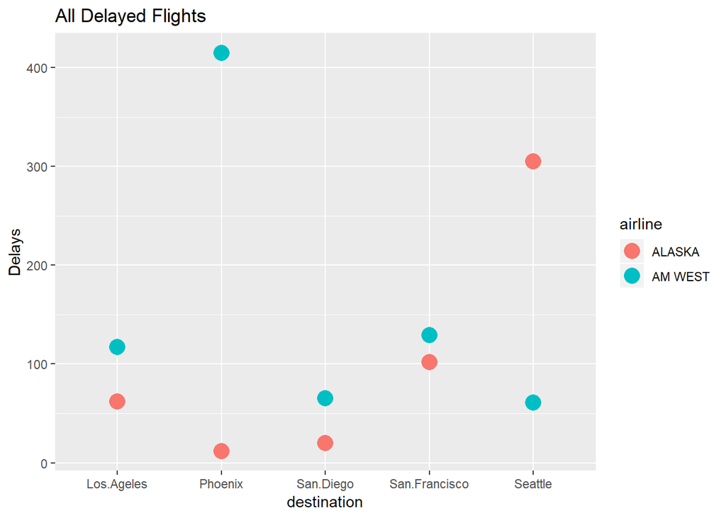

```r
ggplot(filter(df2, flightStatus=="delayed"),aes(destination,tally,color=airline))+geom_point(size=5)+ggtitle("All Delayed Flights")+ylab("Delays")
```

##### From the plot above, AM West airline had so much delayed flight to Phoenix

Let’s see how these stack up against each other on a Bar plot when we sum the total flights per airline per city

```r
r<-df2 %>% spread(flightStatus,tally)%>%mutate(numFlights = rowSums(.[,3:4]), freq= .[,3]/numFlights)
r
```

```
##    airline   destination delayed on time numFlights       freq
## 1   ALASKA    Los.Ageles      62     497        559 0.11091234
## 2   ALASKA       Phoenix      12     221        233 0.05150215
## 3   ALASKA     San.Diego      20     212        232 0.08620690
## 4   ALASKA San.Francisco     102     503        605 0.16859504
## 5   ALASKA       Seattle     305    1841       2146 0.14212488
## 6  AM WEST    Los.Ageles     117     694        811 0.14426634
## 7  AM WEST       Phoenix     415    4840       5255 0.07897241
## 8  AM WEST     San.Diego      65     383        448 0.14508929
## 9  AM WEST San.Francisco     129     320        449 0.28730512
## 10 AM WEST       Seattle      61     201        262 0.23282443
```

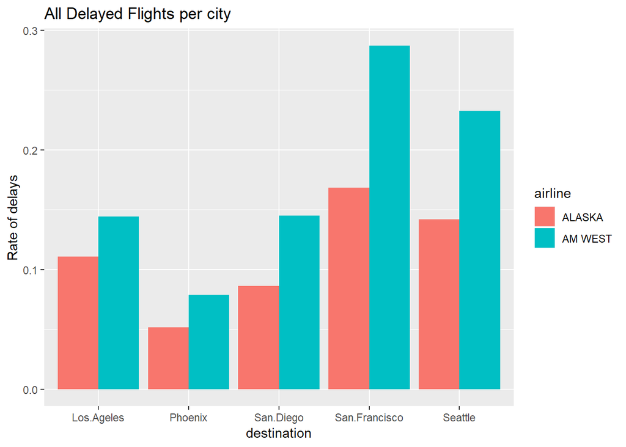

```r
ggplot(r,aes(x=destination,y=freq))+geom_bar(aes(fill=airline),stat="identity",position="dodge")+ylab("Rate of delays")+ggtitle("All Delayed Flights per city")
```

## Conclusion

4. Your code should be in an R Markdown file, posted to rpubs.com, and should include narrative descriptions of your data cleanup work, analysis, and conclusions. Please include in your homework submission: ??? The URL to the .Rmd file in your GitHub repository. and ??? The URL for your rpubs.com web page.

##### In conclusion:

##### From the plots above, it is evident that Alaska Airline performs better as it has the lowest delays per city. Therefore, this can be a good helper in terms of deciding which airline to board when going to any of these cities.

##### If the overall results are considered, AM WEST performs better but when looked at city by city, ALASKA airline has a better performance